# STA208 Final Project

## Predicting Marine Organism Conservation Status

**Author:** Evan Batzer

**Date:** 6/2/2020

### 0. Background

### 1. Assemblying Dataset

#### 1.1 Querying FishBase API

```python
# All available species
taxaTable = extract_fishbase("taxa")

# General species characteristics
speciesTable = extract_fishbase("species")

# Species ecology (habitat type, prey, etc.)
ecologyTable = extract_fishbase("ecology")

# Ecosystem characteristics
ecosystemTable = extract_fishbase("ecosystem")

# Maturity / reproduction
reproTable = extract_fishbase("maturity")
```

[output not shown]

[output not shown]

[output cut: 17 more lines]

[output not shown]

```python
features = taxa_subset.join([spec_subset, eco_subset, repro_subset, ecosys_full])
features.head()
```

| SpecCode | Genus | Species | Family | Order | Class | Vulnerability | Length | Weight | GameFish | Imp_ | ... | brackish | tropical | subtropical | polar | temperate | boreal | Area | AverageDepth | TempSurface | TempDepth |
| --- | --- | --- | --- | --- | --- | --- | --- | --- | --- | --- | --- | --- | --- | --- | --- | --- | --- | --- | --- | --- | --- |
| 48039 | Abyssocottus | elochini | Abyssocottidae | Scorpaeniformes | Actinopterygii | 40.29 | NaN | NaN | 0.0 | 0.0 | ... | NaN | NaN | NaN | NaN | NaN | NaN | NaN | NaN | NaN | NaN |
| 48040 | Abyssocottus | gibbosus | Abyssocottidae | Scorpaeniformes | Actinopterygii | 35.49 | 14.0 | NaN | 0.0 | 0.0 | ... | NaN | NaN | NaN | NaN | NaN | NaN | NaN | NaN | NaN | NaN |
| 47208 | Abyssocottus | korotneffi | Abyssocottidae | Scorpaeniformes | Actinopterygii | 32.97 | 12.6 | NaN | 0.0 | 0.0 | ... | NaN | NaN | NaN | NaN | NaN | NaN | NaN | NaN | NaN | NaN |
| 48048 | Asprocottus | abyssalis | Abyssocottidae | Scorpaeniformes | Actinopterygii | 38.21 | NaN | NaN | 0.0 | 0.0 | ... | NaN | NaN | NaN | NaN | NaN | NaN | NaN | NaN | NaN | NaN |
| 48049 | Asprocottus | herzensteini | Abyssocottidae | Scorpaeniformes | Actinopterygii | 33.02 | 11.5 | NaN | 0.0 | 0.0 | ... | NaN | NaN | NaN | NaN | NaN | NaN | NaN | NaN | NaN | NaN |

5 rows × 74 columns

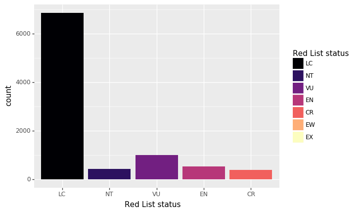

```python
(ggplot(data_labelled,
       aes(x = 'Red List status',
          fill = 'Red List status')) +
 geom_bar() +
scale_fill_cmap_d("magma"))
```

### 2. Binary Classification -- "Least Concern" vs. Others

The simplest way to look at this data is through a binary classification between the "Least Concern" class and all others that reflect some degree of vulnerability to extinction. This approach is common in published studies that have examined this problem.

```python
scaler = StandardScaler()

# Standardizing quantitative columns
quantcols = ['Length', 'Weight','DietTLu','Area','AverageDepth','TempSurface','TempDepth', 'Age_Maturity', 'Length_Maturity']
quant_std = pd.DataFrame(scaler.fit_transform(features_bin[quantcols]),
                           columns = quantcols)

# Standardized dataset (lots of NA's!)
features_std = pd.concat([quant_std, features_bin.drop(quantcols, axis = 1)], axis = 1)
features_std.head()
```

|  | Length | Weight | DietTLu | Area | AverageDepth | TempSurface | TempDepth | Age_Maturity | Length_Maturity | GameFish | ... | Lakes | Cave | freshwater | saltwater | brackish | tropical | subtropical | polar | temperate | boreal |
| --- | --- | --- | --- | --- | --- | --- | --- | --- | --- | --- | --- | --- | --- | --- | --- | --- | --- | --- | --- | --- | --- |
| 0 | -0.139854 | NaN | -0.455351 | NaN | NaN | NaN | NaN | NaN | NaN | 0.0 | ... | 0.0 | 0.0 | 1.0 | 1.0 | 0.0 | 1.0 | 0.0 | 0.0 | 0.0 | 0.0 |
| 1 | 0.017366 | NaN | -0.455351 | NaN | NaN | NaN | NaN | NaN | NaN | 0.0 | ... | 0.0 | 0.0 | 0.0 | 0.0 | 0.0 | 1.0 | 0.0 | 0.0 | 0.0 | 0.0 |
| 2 | 0.226993 | NaN | -0.455351 | 1.052117 | 0.489980 | 0.009435 | 0.154410 | NaN | NaN | 0.0 | ... | 0.0 | 0.0 | 1.0 | 0.0 | 0.0 | 1.0 | 0.0 | 0.0 | 0.0 | 0.0 |
| 3 | NaN | NaN | NaN | NaN | NaN | NaN | NaN | NaN | NaN | 0.0 | ... | NaN | NaN | NaN | NaN | NaN | NaN | NaN | NaN | NaN | NaN |
| 4 | 0.314337 | NaN | -0.455351 | -0.493121 | -0.090207 | 0.308765 | 0.197353 | NaN | NaN | 0.0 | ... | 0.0 | 0.0 | 1.0 | 0.0 | 0.0 | 1.0 | 0.0 | 0.0 | 0.0 | 0.0 |

5 rows × 66 columns

```python
# Initializing cross-validation search
random_search = RandomizedSearchCV(xgb_classifier, param_distributions=params,
                                   n_iter=param_comb, scoring='accuracy', n_jobs=4,
                                   cv=skf.split(x_full,y_full), verbose=3, random_state=0)

# Running randomized CV search
random_search.fit(x_full, y_full)

random_search.best_score_
```

```
Fitting 5 folds for each of 25 candidates, totalling 125 fits
```

```
[Parallel(n_jobs=4)]: Using backend LokyBackend with 4 concurrent workers.
[Parallel(n_jobs=4)]: Done  24 tasks      | elapsed:  1.0min
[Parallel(n_jobs=4)]: Done 125 out of 125 | elapsed:  9.3min finished
```

[output not shown]

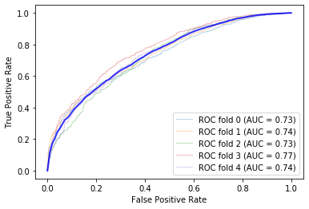

```python
tprs = []
aucs = []
mean_fpr = np.linspace(0, 1, 100)
x_full = x_full.to_numpy()

bestmod_1 = copy.copy(random_search.best_estimator_)

fig, ax = plt.subplots()
for i, (train, test) in enumerate(skf.split(x_full,y_full)):
    bestmod_1.fit(x_full[train], y_full[train])
    viz = plot_roc_curve(bestmod_1, x_full[test], y_full[test],
                         name='ROC fold {}'.format(i),
                         alpha=0.3, lw=1, ax=ax)
    interp_tpr = np.interp(mean_fpr, viz.fpr, viz.tpr)
    interp_tpr[0] = 0.0
    tprs.append(interp_tpr)
    aucs.append(viz.roc_auc)

mean_tpr = np.mean(tprs, axis=0)
mean_tpr[-1] = 1.0
mean_auc = auc(mean_fpr, mean_tpr)
std_auc = np.std(aucs)
ax.plot(mean_fpr, mean_tpr, color='b',
        label=r'Mean ROC (AUC = %0.2f $\pm$ %0.2f)' % (mean_auc, std_auc),
        lw=2, alpha=.8)
```

### 3. Imputing Missing Features

Ideally, imputation could be constructed using phylogenetic information from different species -- the genetic relationships that describe how similar species are to one another on an evolutionary scale. Given the scope of this dataset, however, a full *time-calibrated phylogeny of all fish species* is not available.

However, many features are predictive of one another. Larger fish, for example, are likely to have longer times to maturity and slower reproductive rates. Approches like K-Nearest Neighbors or Random Forest based imputation are known to be [effective imputers for species trait data](https://besjournals.onlinelibrary.wiley.com/doi/10.1111/2041-210X.12232) in certain circumstances.

```python
# imputer = IterativeImputer(estimator = KNeighborsRegressor(n_neighbors=5),
#                            add_indicator=True)

# data_imputed = imputer.fit_transform(features_std)
```

### 4. Binary Classification - Imputed Data

```python
x_full = pd.read_csv('data/imputed_features.csv') # Standardized predictors
y_full = data_labelled["Red List status"] == "LC" * 1 # Classes - whether "Least Concern" or not

# Initializing cross-validation search
random_search = RandomizedSearchCV(xgb_classifier, param_distributions=params,
                                   n_iter=param_comb, scoring='accuracy', n_jobs=4,
                                   cv=skf.split(x_full,y_full), verbose=3, random_state=0)

# Running randomized CV search
random_search.fit(x_full, y_full)

random_search.best_score_
```

```
Fitting 5 folds for each of 25 candidates, totalling 125 fits
```

```
[Parallel(n_jobs=4)]: Using backend LokyBackend with 4 concurrent workers.
[Parallel(n_jobs=4)]: Done  24 tasks      | elapsed:  1.5min
[Parallel(n_jobs=4)]: Done 125 out of 125 | elapsed: 12.9min finished
```

```
0.783114033016083
```

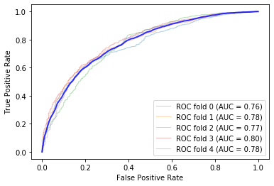

```python
tprs = []
aucs = []
mean_fpr = np.linspace(0, 1, 100)
x_full = x_full.to_numpy()

bestmod_2 = copy.copy(random_search.best_estimator_)

fig, ax = plt.subplots()
for i, (train, test) in enumerate(skf.split(x_full,y_full)):
    bestmod_2.fit(x_full[train], y_full[train])
    viz = plot_roc_curve(bestmod_2, x_full[test], y_full[test],
                         name='ROC fold {}'.format(i),
                         alpha=0.3, lw=1, ax=ax)
    interp_tpr = np.interp(mean_fpr, viz.fpr, viz.tpr)
    interp_tpr[0] = 0.0
    tprs.append(interp_tpr)
    aucs.append(viz.roc_auc)

mean_tpr = np.mean(tprs, axis=0)
mean_tpr[-1] = 1.0
mean_auc = auc(mean_fpr, mean_tpr)
std_auc = np.std(aucs)
ax.plot(mean_fpr, mean_tpr, color='b',
        label=r'Mean ROC (AUC = %0.2f $\pm$ %0.2f)' % (mean_auc, std_auc),
        lw=2, alpha=.8)
```

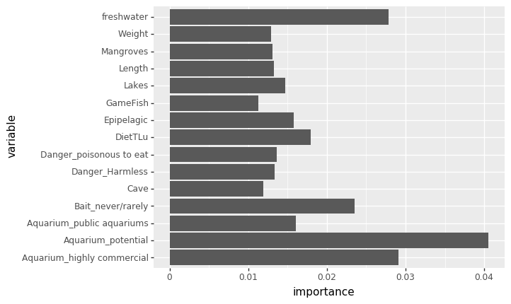

```python
var_imp = pd.concat([pd.Series(bestmod_2.feature_importances_),
             pd.Series(imputed_cols)],axis = 1)
var_imp.columns=["importance", "variable"]
var_imp.sort_values('importance')

(ggplot(aes(y = 'importance',
            x = 'variable'),
       (var_imp.iloc[:-40,].sort_values('importance', ascending=False))[:15]) +
 geom_bar(stat = "identity") +
 coord_flip())
```

### 5. Ordinal Classification - Conservation Status as a pseudo-numeric scale

The key next step in this project is to adapt an ordinal classification method to this data. Several approaches seem possible, though the most promising is to adapt our learning objective to a binary classifier, like SVM, by decomposing ordinal classes into a series of sequential tasks:

- $P(y_i = LC) = 1 - P(y_i > LC)$
- $P(y_i = NT) = P(y_i > LC) - P(y_i > NT)$

$\dots$

- $P(y_i = CR) = P(y_i > CR)$